# Lista 1 - Econometria das Séries Financeiras

Ref: Aula 20/4/2016

Bruno Campos

Pedro Mattos #333791

Renata Polete #330696

Prof: Gustavo Soares

Importando algumas bibliotecas que serão utilizadas:

```python
%matplotlib inline

import datetime
import matplotlib.pyplot as plt
import numpy as np
import pandas as pd
import csv
import urllib

from pandas.tools.plotting import autocorrelation_plot
from yahoo_finance import Share
import statsmodels as sm
import statsmodels.api as sma
```

Criando a lista de ações e capturando os preços:

```python
stocks = ['BRPR3.SA','ENBR3.SA','BVMF3.SA','PETR4.SA','VALE5.SA']

prices = pd.DataFrame()
for stock in stocks:
    s = Share(stock).get_historical('2000-01-01', '2015-12-31')
    s = pd.DataFrame(s).pivot_table(index = "Date", columns = "Symbol", values = "Adj_Close",aggfunc = "last")
    prices = pd.concat([prices, s],axis=1)
```

```python
prices.index = pd.to_datetime(prices.index)
prices = prices["2006-01-01":]
prices = prices.replace(to_replace='NaN',value=np.nan)
prices = prices.fillna(method='ffill')
# prices = prices.fillna(method='bfill')
prices = prices.convert_objects(convert_numeric=True)
```

```python
dailyPrices = prices
dailyPrices.head()
```

| Symbol | BRPR3.SA | ENBR3.SA | BVMF3.SA | PETR4.SA | VALE5.SA |
| --- | --- | --- | --- | --- | --- |
| 2006-01-02 | NaN | 3.76599 | NaN | 14.87216 | 16.07684 |
| 2006-01-03 | NaN | 3.79368 | NaN | 15.34070 | 16.75587 |
| 2006-01-04 | NaN | 3.84906 | NaN | 15.41488 | 16.94715 |
| 2006-01-05 | NaN | 3.91829 | NaN | 15.38365 | 17.06382 |
| 2006-01-06 | NaN | 4.06921 | NaN | 15.94980 | 17.03705 |

```python
weeklyPrices = prices.resample(rule="W").last()
weeklyPrices.head()
```

| Symbol | BRPR3.SA | ENBR3.SA | BVMF3.SA | PETR4.SA | VALE5.SA |
| --- | --- | --- | --- | --- | --- |
| 2006-01-08 | NaN | 4.06921 | NaN | 15.94980 | 17.03705 |
| 2006-01-15 | NaN | 4.25751 | NaN | 16.63308 | 17.69504 |
| 2006-01-22 | NaN | 4.12597 | NaN | 17.27732 | 17.96091 |
| 2006-01-29 | NaN | 4.59674 | NaN | 17.56625 | 18.47736 |
| 2006-02-05 | NaN | 4.56903 | NaN | 17.25389 | 17.67400 |

```python
monthlyPrices = prices.resample(rule="M").last()
monthlyPrices.head()
```

| Symbol | BRPR3.SA | ENBR3.SA | BVMF3.SA | PETR4.SA | VALE5.SA |
| --- | --- | --- | --- | --- | --- |
| 2006-01-31 | NaN | 4.63686 | NaN | 18.35105 | 18.70690 |
| 2006-02-28 | NaN | 4.49979 | NaN | 17.46083 | 17.29144 |
| 2006-03-31 | NaN | 4.17996 | NaN | 16.84392 | 17.88632 |
| 2006-04-30 | NaN | 4.29211 | NaN | 18.35867 | 17.69313 |
| 2006-05-31 | NaN | 3.87675 | NaN | 17.47310 | 16.84768 |

```python
annualPrices = prices.resample(rule="A").last()
annualPrices.head()
```

| Symbol | BRPR3.SA | ENBR3.SA | BVMF3.SA | PETR4.SA | VALE5.SA |
| --- | --- | --- | --- | --- | --- |
| 2006-12-31 | NaN | 4.56903 | NaN | 19.77637 | 20.69618 |
| 2007-12-31 | NaN | 4.00136 | NaN | 37.73657 | 38.82924 |
| 2008-12-31 | NaN | 3.60082 | NaN | 20.10489 | 18.27843 |
| 2009-12-31 | NaN | 5.94648 | NaN | 33.00015 | 32.28757 |
| 2010-12-31 | 10.08 | 8.28072 | NaN | 24.94755 | 37.73885 |

```python
dailyReturns = dailyPrices.pct_change()
dailyReturns.head()
```

| Symbol | BRPR3.SA | ENBR3.SA | BVMF3.SA | PETR4.SA | VALE5.SA |
| --- | --- | --- | --- | --- | --- |
| 2006-01-02 | NaN | NaN | NaN | NaN | NaN |
| 2006-01-03 | NaN | 0.007353 | NaN | 0.031505 | 0.042237 |
| 2006-01-04 | NaN | 0.014598 | NaN | 0.004836 | 0.011416 |
| 2006-01-05 | NaN | 0.017986 | NaN | -0.002026 | 0.006884 |
| 2006-01-06 | NaN | 0.038517 | NaN | 0.036802 | -0.001569 |

```python
weeklyReturns = weeklyPrices.pct_change()
weeklyReturns.head()
```

| Symbol | BRPR3.SA | ENBR3.SA | BVMF3.SA | PETR4.SA | VALE5.SA |
| --- | --- | --- | --- | --- | --- |
| 2006-01-08 | NaN | NaN | NaN | NaN | NaN |
| 2006-01-15 | NaN | 0.046274 | NaN | 0.042839 | 0.038621 |
| 2006-01-22 | NaN | -0.030896 | NaN | 0.038732 | 0.015025 |
| 2006-01-29 | NaN | 0.114099 | NaN | 0.016723 | 0.028754 |
| 2006-02-05 | NaN | -0.006028 | NaN | -0.017782 | -0.043478 |

```python
monthlyReturns = monthlyPrices.pct_change()
monthlyReturns.head()
```

| Symbol | BRPR3.SA | ENBR3.SA | BVMF3.SA | PETR4.SA | VALE5.SA |
| --- | --- | --- | --- | --- | --- |
| 2006-01-31 | NaN | NaN | NaN | NaN | NaN |
| 2006-02-28 | NaN | -0.029561 | NaN | -0.048511 | -0.075665 |
| 2006-03-31 | NaN | -0.071077 | NaN | -0.035331 | 0.034403 |
| 2006-04-30 | NaN | 0.026830 | NaN | 0.089929 | -0.010801 |
| 2006-05-31 | NaN | -0.096773 | NaN | -0.048237 | -0.047784 |

```python
annualReturns = annualPrices.pct_change()
annualReturns.head()
```

| Symbol | BRPR3.SA | ENBR3.SA | BVMF3.SA | PETR4.SA | VALE5.SA |
| --- | --- | --- | --- | --- | --- |
| 2006-12-31 | NaN | NaN | NaN | NaN | NaN |
| 2007-12-31 | NaN | -0.124243 | NaN | 0.908165 | 0.876155 |
| 2008-12-31 | NaN | -0.100101 | NaN | -0.467231 | -0.529261 |
| 2009-12-31 | NaN | 0.651424 | NaN | 0.641399 | 0.766430 |
| 2010-12-31 | NaN | 0.392541 | NaN | -0.244017 | 0.168835 |

# Item: Estatísticas Descritivas e hipótese de log normalidade

## Daily Returns

```python
dailyReturns.mean()
```

```
Symbol
BRPR3.SA    0.000308
ENBR3.SA    0.000654
BVMF3.SA    0.000338
PETR4.SA    0.000034
VALE5.SA    0.000110
dtype: float64
```

```python
dailyReturns.skew()
```

```
Symbol
BRPR3.SA    0.134271
ENBR3.SA    0.194469
BVMF3.SA    0.197623
PETR4.SA    0.227549
VALE5.SA    0.136003
dtype: float64
```

```python
dailyReturns.kurt()
```

```
Symbol
BRPR3.SA    2.419748
ENBR3.SA    2.693506
BVMF3.SA    1.127164
PETR4.SA    3.724426
VALE5.SA    3.783333
dtype: float64
```

```
array([[<matplotlib.axes._subplots.AxesSubplot object at 0x114ed98d0>,
        <matplotlib.axes._subplots.AxesSubplot object at 0x114e19080>]], dtype=object)
```

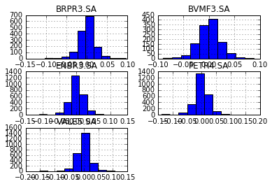

```python
dailyReturns.hist()
```

As médias são muito próximas de zero, o que corrobora com a hipótese de log normalidade. Porém as assimetrias são positivas. As curtoses são razoavelmente diferente de 3 para todos os ativos.

## Weekly Returns

```python
weeklyReturns.mean()
```

```
Symbol
BRPR3.SA    0.001296
ENBR3.SA    0.002903
BVMF3.SA    0.001765
PETR4.SA   -0.000143
VALE5.SA    0.000212
dtype: float64
```

```python
weeklyReturns.skew()
```

```
Symbol
BRPR3.SA   -0.009248
ENBR3.SA    0.173600
BVMF3.SA    0.087060
PETR4.SA   -0.040946
VALE5.SA    0.415477
dtype: float64
```

```python
weeklyReturns.kurt()
```

```
Symbol
BRPR3.SA    0.765345
ENBR3.SA    1.222890
BVMF3.SA    0.773723
PETR4.SA    1.610172
VALE5.SA    2.185269
dtype: float64
```

```
array([[<matplotlib.axes._subplots.AxesSubplot object at 0x114881358>,
        <matplotlib.axes._subplots.AxesSubplot object at 0x1183cd080>]], dtype=object)
```

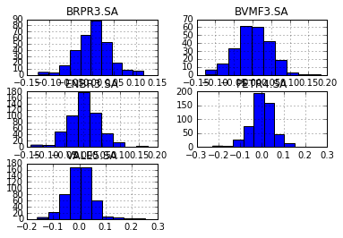

```python
weeklyReturns.hist()
```

## Monthly Returns

```python
monthlyReturns.mean()
```

```
Symbol
BRPR3.SA    0.005648
ENBR3.SA    0.010418
BVMF3.SA    0.006392
PETR4.SA   -0.002410
VALE5.SA   -0.001394
dtype: float64
```

```python
monthlyReturns.skew()
```

```
Symbol
BRPR3.SA    0.608098
ENBR3.SA    0.052785
BVMF3.SA   -0.056189
PETR4.SA    0.038654
VALE5.SA    0.210973
dtype: float64
```

```python
monthlyReturns.kurt()
```

```
Symbol
BRPR3.SA    1.642662
ENBR3.SA   -0.056832
BVMF3.SA   -0.553015
PETR4.SA    0.577951
VALE5.SA    0.726542
dtype: float64
```

```
array([[<matplotlib.axes._subplots.AxesSubplot object at 0x1184df940>,
        <matplotlib.axes._subplots.AxesSubplot object at 0x118827f60>]], dtype=object)
```

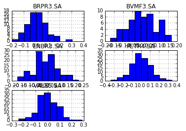

```python
monthlyReturns.hist()
```

## Conclusão

a hipótese de log-normalidade é ainda assim utilizada, principalmente na precificação de derivativos, pois em diversos casos e modelos é muito difícil encontrar uma solução analítica sem assumir esta hipótese como verdadeira.

# Item: Calcule a FAC dos log-retornos diários, semanais e mensais e ajuste um modelo ARIMA

## Autocorrelação

```python
def plotAutoCorr(returns):
    for stock in returns.columns:
        plt.figure()
        plt.title(stock)
        autocorrelation_plot(returns[stock].dropna())
```

### Daily

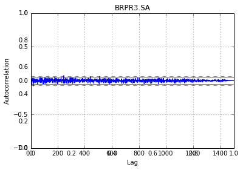

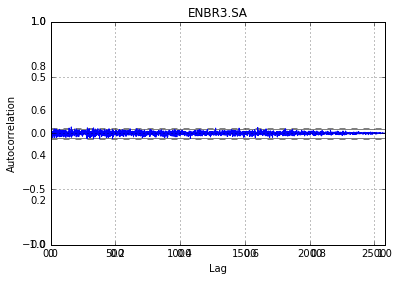

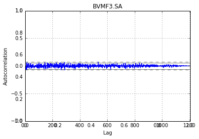

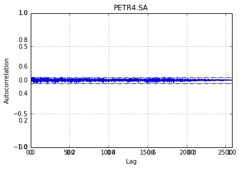

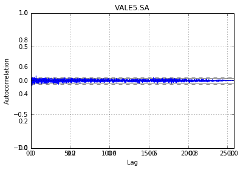

```python
plotAutoCorr(dailyReturns)
```

### Weekly

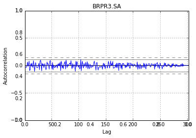

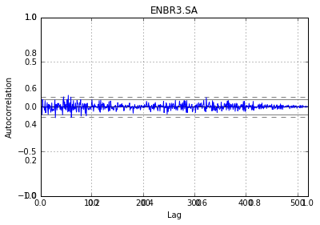

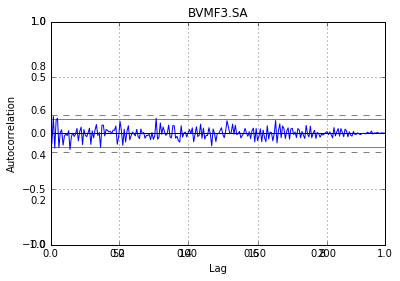

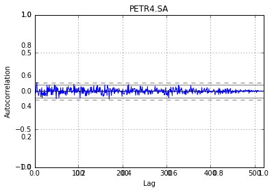

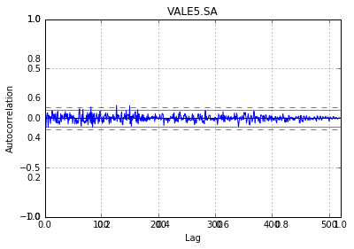

```python
plotAutoCorr(weeklyReturns)
```

### Monthly

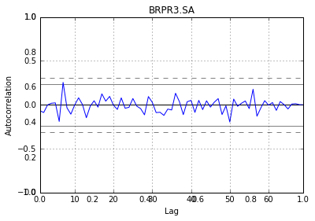

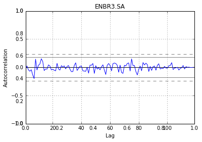

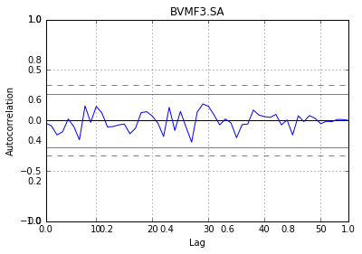

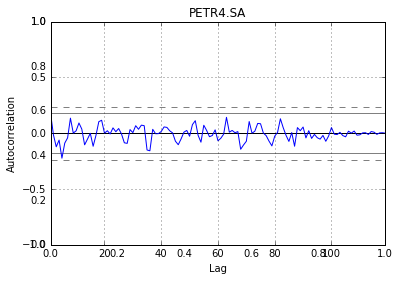

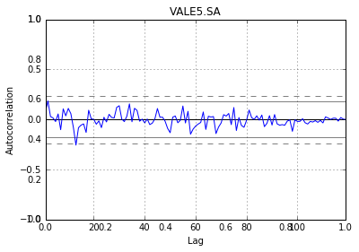

```python
plotAutoCorr(monthlyReturns)
```

Podemos observar que em quase todos os casos a autocorrelação não é estatísticamente diferente de zero. Exceto por alguns casos pontuais que não possuem interpretação lógica. Consideramos estes casos como aleatoriedade.

## ARIMA Model

```python
def estimateArimaForStocks(data,p=2,d=2,q=0):
    for stock in data.columns:
        print('\n\n\n\n Stocks: ' + stock + '\n\n')
        model = sm.tsa.arima_model.ARIMA(data[stock].dropna(), (p,d,q)).fit()
        print(model.summary())
```

### Daily

```python
estimateArimaForStocks(dailyReturns)
```

```
 Stocks: BRPR3.SA


                             ARIMA Model Results
==============================================================================
Dep. Variable:            D2.BRPR3.SA   No. Observations:                 1502
Model:                 ARIMA(2, 2, 0)   Log Likelihood                3075.440
Method:                       css-mle   S.D. of innovations              0.031
Date:                Mon, 27 Jun 2016   AIC                          -6142.880
Time:                        00:29:44   BIC                          -6121.622
Sample:                    03-11-2010   HQIC                         -6134.961
                         - 12-31-2015
=====================================================================================
                        coef    std err          z      P>|z|      [95.0% Conf. Int.]
-------------------------------------------------------------------------------------
const             -7.648e-07      0.000     -0.002      0.998        -0.001     0.001
ar.L1.D2.BRPR3.SA    -1.0474      0.023    -46.100      0.000        -1.092    -1.003
ar.L2.D2.BRPR3.SA    -0.4740      0.023    -20.826      0.000        -0.519    -0.429
                                    Roots
=============================================================================
                 Real           Imaginary           Modulus         Frequency
-----------------------------------------------------------------------------
AR.1           -1.1047           -0.9429j            1.4524           -0.3875
AR.2           -1.1047           +0.9429j            1.4524            0.3875
-----------------------------------------------------------------------------




 Stocks: ENBR3.SA


                             ARIMA Model Results
==============================================================================
Dep. Variable:            D2.ENBR3.SA   No. Observations:                 2583
Model:                 ARIMA(2, 2, 0)   Log Likelihood                5056.330
Method:                       css-mle   S.D. of innovations              0.034
Date:                Mon, 27 Jun 2016   AIC                         -10104.661
Time:                        00:29:45   BIC                         -10081.234
Sample:                    01-05-2006   HQIC                        -10096.170
```

[output cut: 86 more lines]

```
Sample:                    01-05-2006   HQIC                         -9464.994
                         - 12-31-2015
=====================================================================================
                        coef    std err          z      P>|z|      [95.0% Conf. Int.]
-------------------------------------------------------------------------------------
const              8.964e-06      0.000      0.029      0.977        -0.001     0.001
ar.L1.D2.VALE5.SA    -0.9644      0.017    -55.439      0.000        -0.999    -0.930
ar.L2.D2.VALE5.SA    -0.4670      0.017    -26.852      0.000        -0.501    -0.433
                                    Roots
=============================================================================
                 Real           Imaginary           Modulus         Frequency
-----------------------------------------------------------------------------
AR.1           -1.0326           -1.0369j            1.4633           -0.3747
AR.2           -1.0326           +1.0369j            1.4633            0.3747
-----------------------------------------------------------------------------
```

### Weekly

```python
estimateArimaForStocks(weeklyReturns)
```

```
 Stocks: BRPR3.SA


                             ARIMA Model Results
==============================================================================
Dep. Variable:            D2.BRPR3.SA   No. Observations:                  301
Model:                 ARIMA(2, 2, 0)   Log Likelihood                 401.833
Method:                       css-mle   S.D. of innovations              0.064
Date:                Mon, 27 Jun 2016   AIC                           -795.667
Time:                        00:29:46   BIC                           -780.839
Sample:                    04-04-2010   HQIC                          -789.733
                         - 01-03-2016
=====================================================================================
                        coef    std err          z      P>|z|      [95.0% Conf. Int.]
-------------------------------------------------------------------------------------
const              2.456e-05      0.001      0.017      0.987        -0.003     0.003
ar.L1.D2.BRPR3.SA    -1.0180      0.050    -20.493      0.000        -1.115    -0.921
ar.L2.D2.BRPR3.SA    -0.5048      0.050    -10.096      0.000        -0.603    -0.407
                                    Roots
=============================================================================
                 Real           Imaginary           Modulus         Frequency
-----------------------------------------------------------------------------
AR.1           -1.0083           -0.9820j            1.4075           -0.3771
AR.2           -1.0083           +0.9820j            1.4075            0.3771
-----------------------------------------------------------------------------




 Stocks: ENBR3.SA


                             ARIMA Model Results
==============================================================================
Dep. Variable:            D2.ENBR3.SA   No. Observations:                  519
Model:                 ARIMA(2, 2, 0)   Log Likelihood                 660.735
Method:                       css-mle   S.D. of innovations              0.068
Date:                Mon, 27 Jun 2016   AIC                          -1313.470
Time:                        00:29:46   BIC                          -1296.462
Sample:                    01-29-2006   HQIC                         -1306.806
```

[output cut: 86 more lines]

```
Sample:                    01-29-2006   HQIC                         -1151.701
                         - 01-03-2016
=====================================================================================
                        coef    std err          z      P>|z|      [95.0% Conf. Int.]
-------------------------------------------------------------------------------------
const             -1.169e-05      0.001     -0.008      0.993        -0.003     0.003
ar.L1.D2.VALE5.SA    -1.0026      0.039    -25.459      0.000        -1.080    -0.925
ar.L2.D2.VALE5.SA    -0.4416      0.039    -11.193      0.000        -0.519    -0.364
                                    Roots
=============================================================================
                 Real           Imaginary           Modulus         Frequency
-----------------------------------------------------------------------------
AR.1           -1.1351           -0.9879j            1.5048           -0.3860
AR.2           -1.1351           +0.9879j            1.5048            0.3860
-----------------------------------------------------------------------------
```

### Monthly

```python
estimateArimaForStocks(monthlyReturns)
```

```
 Stocks: BRPR3.SA


                             ARIMA Model Results
==============================================================================
Dep. Variable:            D2.BRPR3.SA   No. Observations:                   67
Model:                 ARIMA(2, 2, 0)   Log Likelihood                  38.243
Method:                       css-mle   S.D. of innovations              0.136
Date:                Mon, 27 Jun 2016   AIC                            -68.486
Time:                        00:29:46   BIC                            -59.667
Sample:                    06-30-2010   HQIC                           -64.996
                         - 12-31-2015
=====================================================================================
                        coef    std err          z      P>|z|      [95.0% Conf. Int.]
-------------------------------------------------------------------------------------
const                -0.0013      0.007     -0.195      0.846        -0.014     0.012
ar.L1.D2.BRPR3.SA    -0.9953      0.104     -9.551      0.000        -1.200    -0.791
ar.L2.D2.BRPR3.SA    -0.5178      0.105     -4.946      0.000        -0.723    -0.313
                                    Roots
=============================================================================
                 Real           Imaginary           Modulus         Frequency
-----------------------------------------------------------------------------
AR.1           -0.9611           -1.0037j            1.3897           -0.3716
AR.2           -0.9611           +1.0037j            1.3897            0.3716
-----------------------------------------------------------------------------




 Stocks: ENBR3.SA


                             ARIMA Model Results
==============================================================================
Dep. Variable:            D2.ENBR3.SA   No. Observations:                  117
Model:                 ARIMA(2, 2, 0)   Log Likelihood                  82.935
Method:                       css-mle   S.D. of innovations              0.118
Date:                Mon, 27 Jun 2016   AIC                           -157.870
Time:                        00:29:46   BIC                           -146.821
Sample:                    04-30-2006   HQIC                          -153.384
```

[output cut: 86 more lines]

```
Sample:                    04-30-2006   HQIC                          -145.204
                         - 12-31-2015
=====================================================================================
                        coef    std err          z      P>|z|      [95.0% Conf. Int.]
-------------------------------------------------------------------------------------
const                -0.0004      0.004     -0.092      0.927        -0.009     0.008
ar.L1.D2.VALE5.SA    -1.0989      0.081    -13.502      0.000        -1.258    -0.939
ar.L2.D2.VALE5.SA    -0.4899      0.083     -5.920      0.000        -0.652    -0.328
                                    Roots
=============================================================================
                 Real           Imaginary           Modulus         Frequency
-----------------------------------------------------------------------------
AR.1           -1.1216           -0.8851j            1.4288           -0.3937
AR.2           -1.1216           +0.8851j            1.4288            0.3937
-----------------------------------------------------------------------------
```

### Conclusão

# Item: Calcule a FAC do quadrado log-returns diários,semanais e mensais. FAC e a FACP de $r^2$ e ajustar modelo ARIMA.

```python
def plotFacFacp(data):
    for stock in data.columns:
#         print('\n\n\n\n Stocks: ' + stock + '\n\n')
        fig = plt.figure(figsize=(12,8))
        plt.title(stock, y=1.08)
        ax1 = fig.add_subplot(211)
        fig = sma.graphics.tsa.plot_acf(dailySquared[stock].dropna(), lags=40, ax=ax1)
        ax2 = fig.add_subplot(212)
        fig = sma.graphics.tsa.plot_pacf(dailySquared[stock].dropna(), lags=40, ax=ax2)
```

```python
dailySquared = dailyReturns ** 2
weeklySquared = weeklyReturns ** 2
monthlySquared = monthlyReturns ** 2
```

## Squared daily returns

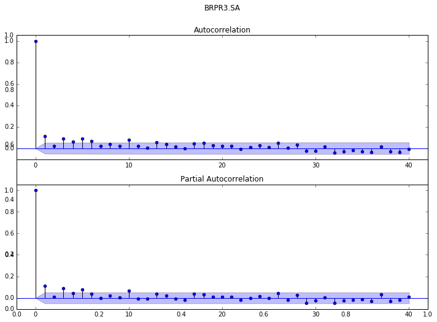

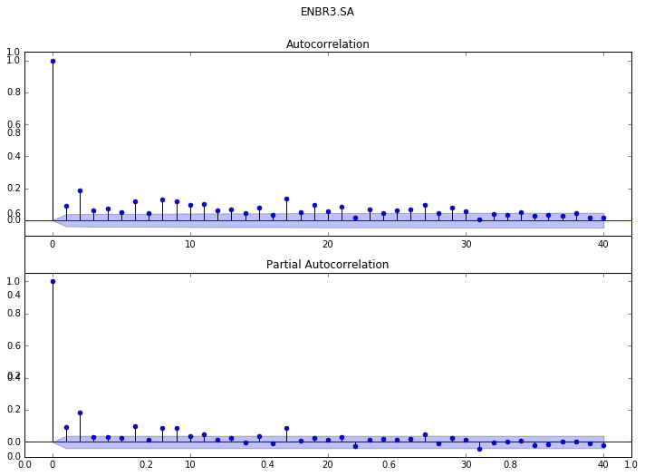

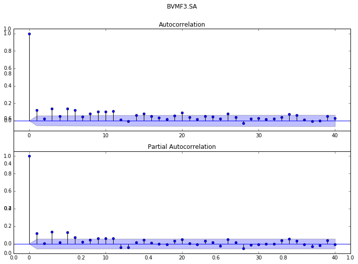

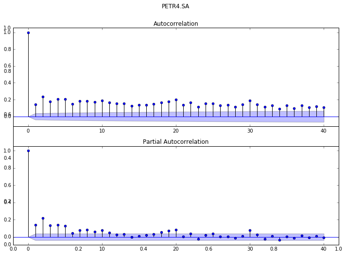

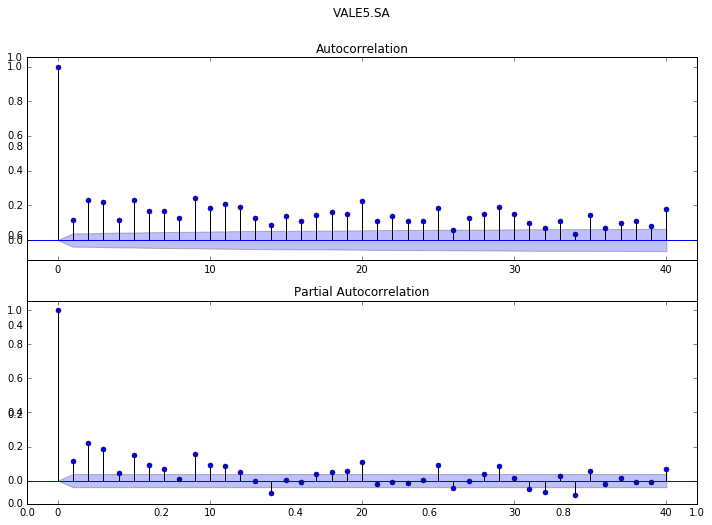

```python
plotFacFacp(dailySquared)
```

```python
estimateArimaForStocks(dailySquared,p=5,d=2,q=0)
```

```
 Stocks: BRPR3.SA


                             ARIMA Model Results
==============================================================================
Dep. Variable:            D2.BRPR3.SA   No. Observations:                 1502
Model:                 ARIMA(5, 2, 0)   Log Likelihood                8252.472
Method:                       css-mle   S.D. of innovations              0.001
Date:                Mon, 27 Jun 2016   AIC                         -16490.944
Time:                        00:29:51   BIC                         -16453.742
Sample:                    03-11-2010   HQIC                        -16477.086
                         - 12-31-2015
=====================================================================================
                        coef    std err          z      P>|z|      [95.0% Conf. Int.]
-------------------------------------------------------------------------------------
const             -7.633e-08   4.19e-06     -0.018      0.985     -8.29e-06  8.14e-06
ar.L1.D2.BRPR3.SA    -1.4016      0.025    -57.186      0.000        -1.450    -1.354
ar.L2.D2.BRPR3.SA    -1.4538      0.039    -37.354      0.000        -1.530    -1.378
ar.L3.D2.BRPR3.SA    -1.1792      0.045    -26.392      0.000        -1.267    -1.092
ar.L4.D2.BRPR3.SA    -0.7690      0.039    -19.740      0.000        -0.845    -0.693
ar.L5.D2.BRPR3.SA    -0.3197      0.025    -13.024      0.000        -0.368    -0.272
                                    Roots
=============================================================================
                 Real           Imaginary           Modulus         Frequency
-----------------------------------------------------------------------------
AR.1            0.2543           -1.1893j            1.2162           -0.2165
AR.2            0.2543           +1.1893j            1.2162            0.2165
AR.3           -0.7890           -0.9802j            1.2583           -0.3579
AR.4           -0.7890           +0.9802j            1.2583            0.3579
AR.5           -1.3356           -0.0000j            1.3356           -0.5000
-----------------------------------------------------------------------------




 Stocks: ENBR3.SA


                             ARIMA Model Results
==============================================================================
```

[output cut: 116 more lines]

```
ar.L1.D2.VALE5.SA    -1.5132      0.019    -80.494      0.000        -1.550    -1.476
ar.L2.D2.VALE5.SA    -1.4985      0.032    -47.018      0.000        -1.561    -1.436
ar.L3.D2.VALE5.SA    -1.1611      0.037    -31.451      0.000        -1.233    -1.089
ar.L4.D2.VALE5.SA    -0.7610      0.032    -23.888      0.000        -0.823    -0.699
ar.L5.D2.VALE5.SA    -0.2953      0.019    -15.714      0.000        -0.332    -0.258
                                    Roots
=============================================================================
                 Real           Imaginary           Modulus         Frequency
-----------------------------------------------------------------------------
AR.1            0.2516           -1.2366j            1.2620           -0.2181
AR.2            0.2516           +1.2366j            1.2620            0.2181
AR.3           -0.8516           -0.9048j            1.2425           -0.3702
AR.4           -0.8516           +0.9048j            1.2425            0.3702
AR.5           -1.3775           -0.0000j            1.3775           -0.5000
-----------------------------------------------------------------------------
```

Podemos observar que exceto pela constante os demais parâmetros são diferentes de zero. O que faz sentido vez que a série em nível tem média zero. O modelo parece estar mais bem ajustado. Isto está de acordo com o esperado, que os retornos ao quadrado possuam melhor ajuste.

## Squared weekly returns

```python
estimateArimaForStocks(weeklySquared,p=5,d=2,q=0)
```

```
 Stocks: BRPR3.SA


                             ARIMA Model Results
==============================================================================
Dep. Variable:            D2.BRPR3.SA   No. Observations:                  301
Model:                 ARIMA(5, 2, 0)   Log Likelihood                1302.548
Method:                       css-mle   S.D. of innovations              0.003
Date:                Mon, 27 Jun 2016   AIC                          -2591.096
Time:                        00:30:00   BIC                          -2565.147
Sample:                    04-04-2010   HQIC                         -2580.713
                         - 01-03-2016
=====================================================================================
                        coef    std err          z      P>|z|      [95.0% Conf. Int.]
-------------------------------------------------------------------------------------
const             -2.571e-06      3e-05     -0.086      0.932     -6.14e-05  5.63e-05
ar.L1.D2.BRPR3.SA    -1.3856      0.055    -25.255      0.000        -1.493    -1.278
ar.L2.D2.BRPR3.SA    -1.4992      0.087    -17.220      0.000        -1.670    -1.329
ar.L3.D2.BRPR3.SA    -1.2131      0.101    -12.070      0.000        -1.410    -1.016
ar.L4.D2.BRPR3.SA    -0.7391      0.087     -8.510      0.000        -0.909    -0.569
ar.L5.D2.BRPR3.SA    -0.3114      0.055     -5.636      0.000        -0.420    -0.203
                                    Roots
=============================================================================
                 Real           Imaginary           Modulus         Frequency
-----------------------------------------------------------------------------
AR.1            0.2114           -1.2045j            1.2229           -0.2224
AR.2            0.2114           +1.2045j            1.2229            0.2224
AR.3           -1.3136           -0.0000j            1.3136           -0.5000
AR.4           -0.7414           -1.0417j            1.2786           -0.3484
AR.5           -0.7414           +1.0417j            1.2786            0.3484
-----------------------------------------------------------------------------




 Stocks: ENBR3.SA
```

```
                             ARIMA Model Results
==============================================================================
Dep. Variable:            D2.ENBR3.SA   No. Observations:                  519
Model:                 ARIMA(5, 2, 0)   Log Likelihood                2135.297
Method:                       css-mle   S.D. of innovations              0.004
Date:                Mon, 27 Jun 2016   AIC                          -4256.593
Time:                        00:30:01   BIC                          -4226.830
Sample:                    01-29-2006   HQIC                         -4244.933
                         - 01-03-2016
=====================================================================================
                        coef    std err          z      P>|z|      [95.0% Conf. Int.]
-------------------------------------------------------------------------------------
const             -9.085e-08   2.99e-05     -0.003      0.998     -5.88e-05  5.86e-05
ar.L1.D2.ENBR3.SA    -1.3366      0.042    -31.590      0.000        -1.420    -1.254
ar.L2.D2.ENBR3.SA    -1.3972      0.066    -21.051      0.000        -1.527    -1.267
ar.L3.D2.ENBR3.SA    -1.1341      0.075    -15.026      0.000        -1.282    -0.986
ar.L4.D2.ENBR3.SA    -0.6679      0.066    -10.055      0.000        -0.798    -0.538
ar.L5.D2.ENBR3.SA    -0.2677      0.043     -6.269      0.000        -0.351    -0.184
                                    Roots
=============================================================================
                 Real           Imaginary           Modulus         Frequency
-----------------------------------------------------------------------------
AR.1            0.2132           -1.2167j            1.2353           -0.2224
AR.2            0.2132           +1.2167j            1.2353            0.2224
AR.3           -1.3310           -0.0000j            1.3310           -0.5000
AR.4           -0.7953           -1.0986j            1.3562           -0.3497
AR.5           -0.7953           +1.0986j            1.3562            0.3497
-----------------------------------------------------------------------------




 Stocks: BVMF3.SA


                             ARIMA Model Results
==============================================================================
Dep. Variable:            D2.BVMF3.SA   No. Observations:                  240
Model:                 ARIMA(5, 2, 0)   Log Likelihood                 946.770
Method:                       css-mle   S.D. of innovations              0.005
```

[output cut: 78 more lines]

```
ar.L1.D2.VALE5.SA    -1.3284      0.042    -31.331      0.000        -1.411    -1.245
ar.L2.D2.VALE5.SA    -1.3450      0.067    -20.180      0.000        -1.476    -1.214
ar.L3.D2.VALE5.SA    -1.0591      0.076    -13.972      0.000        -1.208    -0.911
ar.L4.D2.VALE5.SA    -0.6267      0.067     -9.421      0.000        -0.757    -0.496
ar.L5.D2.VALE5.SA    -0.2565      0.042     -6.057      0.000        -0.340    -0.173
                                    Roots
=============================================================================
                 Real           Imaginary           Modulus         Frequency
-----------------------------------------------------------------------------
AR.1            0.2415           -1.2479j            1.2710           -0.2196
AR.2            0.2415           +1.2479j            1.2710            0.2196
AR.3           -1.3394           -0.0000j            1.3394           -0.5000
AR.4           -0.7935           -1.0826j            1.3423           -0.3507
AR.5           -0.7935           +1.0826j            1.3423            0.3507
-----------------------------------------------------------------------------
```

Em geral temos resultados parecidos com o anterior, dentro do esperado. Coeficientes siginificantes exceto pela constante.

# VAR

Precisamos criar a série de dividend yield

```python
def getDividends(stock,initialDate,finalDate):
    initialDate = datetime.datetime.strptime(initialDate,"%Y-%m-%d")
    finalDate = datetime.datetime.strptime(finalDate,"%Y-%m-%d")
    url="""http://ichart.yahoo.com/table.csv?s={stock}&c={initialYear!s}&a={initialMonth!s}&b={initialDay!s}&f={finalYear!s}&d={finalMonth!s}&e={finalDay!s}&g=v&ignore=.csv""".format(stock=stock,initialYear=initialDate.year,
                              initialMonth=initialDate.month,initialDay=initialDate.day,
                              finalYear=finalDate.year,finalMonth=finalDate.month,
                              finalDay=finalDate.day)
    csvStr = urllib.request.urlopen(url)
    df = pd.read_csv(csvStr)
#     df.pivot_table(index="Date", columns=stock, values="Dividends")
    df.set_index(keys='Date',inplace=True)
    df.columns = [stock]
    return df
```

```python
dividends = pd.DataFrame()
for stock in stocks:
    s = getDividends(stock,"2000-01-01","2015-12-31")
    dividends = pd.concat([dividends, s],axis=1)

dividends = dividends["2006-01-01":]
dividends.set_index(pd.to_datetime(dividends.index),inplace=True)
dividends.head()
```

|  | BRPR3.SA | ENBR3.SA | BVMF3.SA | PETR4.SA | VALE5.SA |
| --- | --- | --- | --- | --- | --- |
| 2006-04-04 | NaN | NaN | NaN | 0.3715 | NaN |
| 2007-01-02 | NaN | NaN | NaN | 0.4500 | NaN |
| 2007-04-03 | NaN | NaN | NaN | 0.3500 | NaN |
| 2007-08-20 | NaN | NaN | NaN | 0.5034 | NaN |
| 2007-10-08 | NaN | NaN | NaN | 0.5130 | NaN |

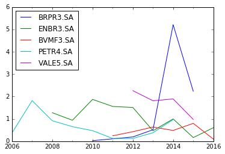

```python
yearDividends = dividends.resample('A').sum()
yearDividends.plot()
```

Tivemos que mudar a frequência para anual pois as ações não pagam dividendos com muita frequência. Infelizmente isto torna nossa amostra pequena demais para esperarmos conclusões robustas.

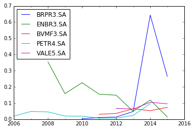

```python
dividendYield = yearDividends / annualPrices
dividendYield.plot()
```

```python
import statsmodels.tsa.vector_ar.var_model as smvar
```

Por conta da discontinuidade dos dados iremos utilizar apenas as séries de ENBR3 e PETR4

## VAR ENBR3

```python
varData = pd.concat([pd.DataFrame(annualReturns['ENBR3.SA']), pd.DataFrame(dividendYield['ENBR3.SA'])], axis=1)
varData.columns = ['Returns','DividendYield']
varData = varData.fillna(0)
varData.head()
```

|  | Returns | DividendYield |
| --- | --- | --- |
| 2006-12-31 | 0.000000 | 0.000000 |
| 2007-12-31 | -0.124243 | 0.000000 |
| 2008-12-31 | -0.100101 | 0.354245 |
| 2009-12-31 | 0.651424 | 0.157802 |
| 2010-12-31 | 0.392541 | 0.225732 |

```python
model1 = smvar.VAR(varData)
results1 = model1.fit(1)
results1.summary()
```

```
  Summary of Regression Results
==================================
Model:                         VAR
Method:                        OLS
Date:           Mon, 27, Jun, 2016
Time:                     00:30:08
--------------------------------------------------------------------
No. of Equations:         2.00000    BIC:                   -6.93719
Nobs:                     10.0000    HQIC:                  -7.31790
Log likelihood:           13.2149    FPE:                0.000841214
AIC:                     -7.11874    Det(Omega_mle):     0.000497760
--------------------------------------------------------------------
Results for equation Returns
===================================================================================
                      coefficient       std. error           t-stat            prob
-----------------------------------------------------------------------------------
const                   -0.120007         0.087088           -1.378           0.211
L1.Returns               0.069532         0.220121            0.316           0.761
L1.DividendYield         1.915964         0.523903            3.657           0.008
===================================================================================

Results for equation DividendYield
===================================================================================
                      coefficient       std. error           t-stat            prob
-----------------------------------------------------------------------------------
const                    0.103957         0.062502            1.663           0.140
L1.Returns               0.028521         0.157980            0.181           0.862
L1.DividendYield         0.121185         0.376002            0.322           0.757
===================================================================================

Correlation matrix of residuals
                  Returns  DividendYield
Returns          1.000000      -0.008917
DividendYield   -0.008917       1.000000
```

O único coeficiente que possui significância a 1% no nosso VAR é a defasagem de DividendYield em Returns exatamente como esperávamos.

```python
model2 = smvar.VAR(varData)
results2 = model2.fit(2)
results2.summary()
```

```
  Summary of Regression Results
==================================
Model:                         VAR
Method:                        OLS
Date:           Mon, 27, Jun, 2016
Time:                     00:30:08
--------------------------------------------------------------------
No. of Equations:         2.00000    BIC:                   -6.77565
Nobs:                     9.00000    HQIC:                  -7.46769
Log likelihood:           15.9356    FPE:                 0.00121686
AIC:                     -6.99479    Det(Omega_mle):     0.000502886
--------------------------------------------------------------------
Results for equation Returns
===================================================================================
                      coefficient       std. error           t-stat            prob
-----------------------------------------------------------------------------------
const                   -0.057336         0.110652           -0.518           0.632
L1.Returns               0.376866         0.313682            1.201           0.296
L1.DividendYield         2.128009         0.473724            4.492           0.011
L2.Returns              -0.456787         0.198911           -2.296           0.083
L2.DividendYield        -0.662871         0.786874           -0.842           0.447
===================================================================================

Results for equation DividendYield
===================================================================================
                      coefficient       std. error           t-stat            prob
-----------------------------------------------------------------------------------
const                    0.144703         0.120144            1.204           0.295
L1.Returns               0.028975         0.340593            0.085           0.936
L1.DividendYield        -0.035255         0.514365           -0.069           0.949
L2.Returns               0.021734         0.215976            0.101           0.925
L2.DividendYield        -0.075168         0.854381           -0.088           0.934
===================================================================================

Correlation matrix of residuals
                  Returns  DividendYield
Returns          1.000000       0.014261
DividendYield    0.014261       1.000000
```

Ao fazer o VAR(2) o único novo coeficiente significante é o segundo lag de retornos nos próprios retornos. Porém como o coeficiente só é significante a 10% consideramos que é obra do acaso. Ficaremos portanto com o VAR(1). Além disto o critério de informação BIC do primeiro modelo é mais negativo.

```python
model1.select_order(2)
```

```
                 VAR Order Selection
=====================================================
           aic          bic          fpe         hqic
-----------------------------------------------------
0       -6.818       -6.774     0.001096       -6.913
1       -6.911      -6.780*    0.001051*       -7.195
2      -6.995*       -6.776     0.001217      -7.468*
=====================================================
* Minimum
```

```
{'aic': 2, 'bic': 1, 'fpe': 1, 'hqic': 2}
```

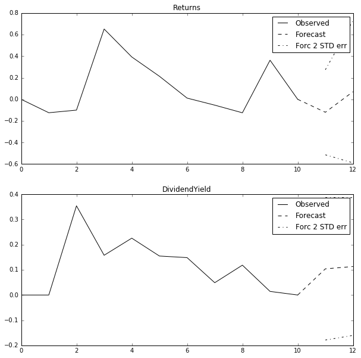

```python
lag_order = results1.k_ar
results1.forecast(varData.values[-lag_order:], 5)
results1.plot_forecast(2)
```

## VAR PETR4

```python
varData = pd.concat([pd.DataFrame(annualReturns['PETR4.SA']), pd.DataFrame(dividendYield['PETR4.SA'])], axis=1)
varData.columns = ['Returns','DividendYield']
varData = varData.fillna(0)
varData.head()
```

|  | Returns | DividendYield |
| --- | --- | --- |
| 2006-12-31 | 0.000000 | 0.018785 |
| 2007-12-31 | 0.908165 | 0.048134 |
| 2008-12-31 | -0.467231 | 0.045541 |
| 2009-12-31 | 0.641399 | 0.019745 |
| 2010-12-31 | -0.244017 | 0.018968 |

```python
model1 = smvar.VAR(varData)
results1 = model1.fit(1)
results1.summary()
```

```
  Summary of Regression Results
==================================
Model:                         VAR
Method:                        OLS
Date:           Mon, 27, Jun, 2016
Time:                     00:30:09
--------------------------------------------------------------------
No. of Equations:         2.00000    BIC:                   -7.72197
Nobs:                     10.0000    HQIC:                  -8.10268
Log likelihood:           17.1388    FPE:                0.000383779
AIC:                     -7.90352    Det(Omega_mle):     0.000227088
--------------------------------------------------------------------
Results for equation Returns
===================================================================================
                      coefficient       std. error           t-stat            prob
-----------------------------------------------------------------------------------
const                    0.041607         0.214896            0.194           0.852
L1.Returns              -0.357627         0.347336           -1.030           0.337
L1.DividendYield        -2.765601         5.465144           -0.506           0.628
===================================================================================

Results for equation DividendYield
===================================================================================
                      coefficient       std. error           t-stat            prob
-----------------------------------------------------------------------------------
const                    0.029198         0.014791            1.974           0.089
L1.Returns               0.019725         0.023906            0.825           0.437
L1.DividendYield        -0.072855         0.376156           -0.194           0.852
===================================================================================

Correlation matrix of residuals
                  Returns  DividendYield
Returns          1.000000       0.077050
DividendYield    0.077050       1.000000
```

```python
model2 = smvar.VAR(varData)
results2 = model2.fit(2)
results2.summary()
```

```
  Summary of Regression Results
==================================
Model:                         VAR
Method:                        OLS
Date:           Mon, 27, Jun, 2016
Time:                     00:30:09
--------------------------------------------------------------------
No. of Equations:         2.00000    BIC:                   -8.40569
Nobs:                     9.00000    HQIC:                  -9.09773
Log likelihood:           23.2708    FPE:                0.000238408
AIC:                     -8.62483    Det(Omega_mle):     9.85258e-05
--------------------------------------------------------------------
Results for equation Returns
===================================================================================
                      coefficient       std. error           t-stat            prob
-----------------------------------------------------------------------------------
const                   -0.230758         0.183889           -1.255           0.278
L1.Returns              -0.188184         0.220338           -0.854           0.441
L1.DividendYield        -1.894186         3.328346           -0.569           0.600
L2.Returns               0.390696         0.230500            1.695           0.165
L2.DividendYield         4.654318         3.529909            1.319           0.258
===================================================================================

Results for equation DividendYield
===================================================================================
                      coefficient       std. error           t-stat            prob
-----------------------------------------------------------------------------------
const                    0.043826         0.025158            1.742           0.156
L1.Returns               0.015497         0.030145            0.514           0.634
L1.DividendYield        -0.147088         0.455355           -0.323           0.763
L2.Returns               0.002824         0.031535            0.090           0.933
L2.DividendYield        -0.469181         0.482931           -0.972           0.386
===================================================================================

Correlation matrix of residuals
                  Returns  DividendYield
Returns          1.000000      -0.091713
DividendYield   -0.091713       1.000000
```

Para PETR4 não encontramos significância nos coeficientes

# Função Resposta a Impulso

Como apenas o VAR de ENBR3 apresentou significância utilizaremos apenas ele.

Como temos apenas 11 pontos na amostra iremos fazer a resposta ao impulso 4 lags a frente.

Os impulsos são calculados em resposta a um choque de uma unidade em cada uma das variáveis.

```python
varData = pd.concat([pd.DataFrame(annualReturns['ENBR3.SA']), pd.DataFrame(dividendYield['ENBR3.SA'])], axis=1)
varData.columns = ['Returns','DividendYield']
varData = varData.fillna(0)
model1 = smvar.VAR(varData)
results1 = model1.fit(1)
```

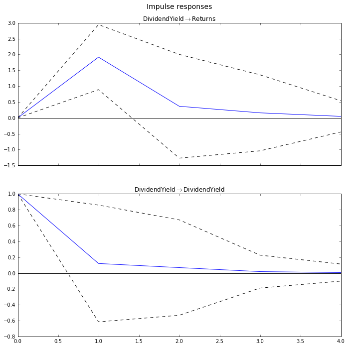

```python
irf = results1.irf(4)
irf.plot(orth=False,impulse='DividendYield')
```

# Lista 02

No último exercício foi estimado o VAR na forma reduzida e os coeficientes obtiveram os valores esperados. Imprevisibilidade dos dividendos porém previsibilidade dos retornos.

Também foi feita a função resposta a impulso, porém devido a escassez de dados não temos choques suficientes para diferenciar entre choques no dividendo e no preço. Ou talvez eu não tenha compreendido bem o exercício.